# Untitled

Sizhe Zhang

2023-11-17

```r
library(ggplot2)
library(carData)
library(car)
library(MASS)
library(lfactors)
library(Dire)
library(EdSurvey)
library(GGally)
```

Necessary packages

```r
load("Project Data.Rdata")
eclsk <- subset(eclsk_c,select = -CHILDID)
##Deleting irrelavant ID
```

## Parameter of choice: Should we use the math results from first three grades?

#### For the rejected parameters, note the strong correlation: in fact they will explain ~75% of the variability (out of ~78%)

```r
rej_model<-lm(rej_eclsk$C6R4MSCL~.,data=rej_eclsk)
summary(rej_model)
```

```
##
## Call:
## lm(formula = rej_eclsk$C6R4MSCL ~ ., data = rej_eclsk)
##
## Residuals:
##     Min      1Q  Median      3Q     Max
## -49.225  -7.235   0.161   7.467  53.078
##
## Coefficients:
##              Estimate Std. Error t value Pr(>|t|)
## (Intercept) 22.303447   0.868781  25.672  < 2e-16 ***
## F5SPECS     -1.668845   0.576728  -2.894  0.00382 **
## C5R4RSCL    -0.060359   0.009887  -6.105 1.08e-09 ***
## C6R4RSCL     0.256425   0.010196  25.149  < 2e-16 ***
## C5R4MSCL     0.711727   0.008139  87.445  < 2e-16 ***
## ---
## Signif. codes:  0 '***' 0.001 '**' 0.01 '*' 0.05 '.' 0.1 ' ' 1
##
## Residual standard error: 11.25 on 7357 degrees of freedom
## Multiple R-squared:  0.7684, Adjusted R-squared:  0.7683
## F-statistic:  6102 on 4 and 7357 DF,  p-value: < 2.2e-16
```

```r
full_model <-lm(C6R4MSCL~.,data=eclsk)
summary(full_model)
```

```
##
## Call:
## lm(formula = C6R4MSCL ~ ., data = eclsk)
##
## Residuals:
##     Min      1Q  Median      3Q     Max
## -48.711  -6.967   0.129   7.179  49.154
##
## Coefficients:
##                Estimate Std. Error t value Pr(>|t|)
## (Intercept)  38.1071889  3.2807894  11.615  < 2e-16 ***
## S1_ID         0.0001251  0.0001663   0.753  0.45173
## GENDER        2.7165512  0.2822060   9.626  < 2e-16 ***
## WKWHITE       0.0346061  0.3899189   0.089  0.92928
## WKSESL        0.3031626  0.2531268   1.198  0.23108
## RIRT         -0.0725169  0.0182129  -3.982 6.91e-05 ***
## MIRT          0.1932068  0.0255258   7.569 4.22e-14 ***
## S2KPUPRI      1.3806287  0.3538322   3.902 9.63e-05 ***
## P1EXPECT     -0.0157660  0.1342604  -0.117  0.90652
## P1FIRKDG      4.4710683  0.7594230   5.887 4.10e-09 ***
## P1AGEENT     -0.3257980  0.0347806  -9.367  < 2e-16 ***
## apprchT1      0.8051795  0.2745006   2.933  0.00336 **
## P1HSEVER     -1.1968748  0.4530819  -2.642  0.00827 **
## chg14         0.0783181  0.5593451   0.140  0.88865
## P1FSTAMP     -0.6312674  0.4787377  -1.319  0.18734
## S2KMINOR      0.0330917  0.1228352   0.269  0.78763
## ONEPARENT    -0.6297532  0.4023052  -1.565  0.11754
## STEPPARENT   -0.2328836  0.5754790  -0.405  0.68573
## P1NUMSIB      0.0093840  0.1283509   0.073  0.94172
## P1HMAFB       0.0940729  0.0301158   3.124  0.00179 **
## WKCAREPK     -0.5513922  0.3675859  -1.500  0.13365
## P1EARLY       0.0020557  0.0126377   0.163  0.87079
## wt_ounces     0.0170723  0.0074781   2.283  0.02246 *
## C1FMOTOR      0.6336000  0.0771083   8.217 2.45e-16 ***
## C1GMOTOR     -0.0949004  0.0762982  -1.244  0.21361
## P1HSCALE     -0.0034101  0.1741900  -0.020  0.98438
## P1SADLON     -0.2213961  0.3571358  -0.620  0.53533
## P1IMPULS      0.0117925  0.2208402   0.053  0.95742
## P1ATTENI     -0.3675797  0.2391531  -1.537  0.12434
## P1SOLVE       0.0372772  0.2583016   0.144  0.88525
## P1PRONOU      0.1056029  0.2333712   0.453  0.65091
## P1DISABL      0.4708131  0.4087474   1.152  0.24942
## F5SPECS      -1.5861649  0.5870149  -2.702  0.00691 **
## C5R4RSCL     -0.0569114  0.0100048  -5.688 1.33e-08 ***
## C6R4RSCL      0.2405845  0.0101104  23.796  < 2e-16 ***
## C5R4MSCL      0.6273311  0.0096512  65.000  < 2e-16 ***
## avg_RIRT     -0.0131031  0.0437459  -0.300  0.76455
## avg_MIRT     -0.0502948  0.0533410  -0.943  0.34577
## avg_SES       1.4066283  0.4434757   3.172  0.00152 **
## avg_apprchT1 -0.2181358  0.5087353  -0.429  0.66810
## ---
## Signif. codes:  0 '***' 0.001 '**' 0.01 '*' 0.05 '.' 0.1 ' ' 1
##
## Residual standard error: 10.95 on 7322 degrees of freedom
## Multiple R-squared:  0.7816, Adjusted R-squared:  0.7804
## F-statistic: 671.8 on 39 and 7322 DF,  p-value: < 2.2e-16
```

And a further PCA on full model:

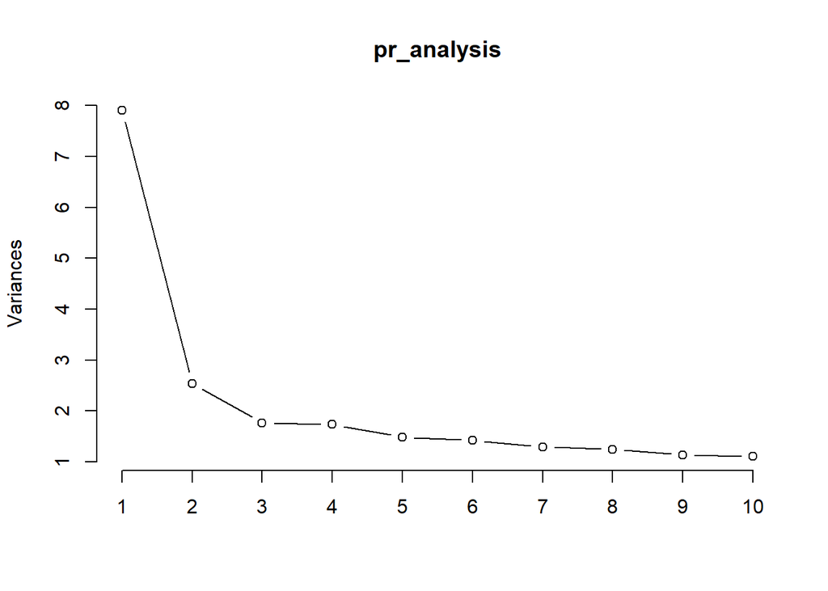

```r
pr_analysis<-prcomp(eclsk,scale=TRUE)
screeplot(pr_analysis,type = 'l')
```

```r
summary(pr_analysis)
```

```
## Importance of components:
##                           PC1    PC2     PC3     PC4     PC5    PC6     PC7
## Standard deviation     2.8112 1.5937 1.32889 1.31630 1.21972 1.1900 1.13751
## Proportion of Variance 0.1976 0.0635 0.04415 0.04332 0.03719 0.0354 0.03235
## Cumulative Proportion  0.1976 0.2611 0.30522 0.34853 0.38572 0.4211 0.45347
##                            PC8     PC9    PC10    PC11    PC12    PC13    PC14
## Standard deviation     1.11477 1.06526 1.05089 1.03437 1.03058 1.01628 0.99241
## Proportion of Variance 0.03107 0.02837 0.02761 0.02675 0.02655 0.02582 0.02462
## Cumulative Proportion  0.48454 0.51291 0.54052 0.56727 0.59382 0.61964 0.64426
##                           PC15    PC16    PC17   PC18    PC19    PC20    PC21
## Standard deviation     0.98292 0.96461 0.94321 0.9295 0.90458 0.88478 0.85951
## Proportion of Variance 0.02415 0.02326 0.02224 0.0216 0.02046 0.01957 0.01847
## Cumulative Proportion  0.66842 0.69168 0.71392 0.7355 0.75597 0.77554 0.79401
##                           PC22    PC23   PC24    PC25    PC26    PC27    PC28
## Standard deviation     0.85007 0.82399 0.8074 0.79903 0.78357 0.76709 0.75051
## Proportion of Variance 0.01807 0.01697 0.0163 0.01596 0.01535 0.01471 0.01408
## Cumulative Proportion  0.81208 0.82905 0.8454 0.86131 0.87666 0.89137 0.90545
##                           PC29    PC30    PC31    PC32    PC33    PC34    PC35
## Standard deviation     0.71431 0.68811 0.66782 0.64736 0.62445 0.60625 0.57771
## Proportion of Variance 0.01276 0.01184 0.01115 0.01048 0.00975 0.00919 0.00834
## Cumulative Proportion  0.91821 0.93004 0.94119 0.95167 0.96142 0.97061 0.97895
##                           PC36    PC37   PC38    PC39    PC40
## Standard deviation     0.47872 0.47010 0.4145 0.33933 0.32375
## Proportion of Variance 0.00573 0.00552 0.0043 0.00288 0.00262
## Cumulative Proportion  0.98468 0.99021 0.9945 0.99738 1.00000
```

## Rationale for eliminating the earlier grades’ scores on math when predicting the fifth grade

#### Data extendability

If we want to predict a kindergarten kid’s capabilities in maths in future at the time of enrollment, 2/3/4-th grades’ scores will not be available

#### Statistical value of model

Predicting a kid’s performance with previous performance seems too easy.

#### Our interest:

To use other available data to draw connection between the environmental factor and education factors on a child’s capability in completing certain tasks.

```r
red_eclsk<-data.frame(scale(red_eclsk,center = TRUE,scale=TRUE))
```

Also improve numerical stability, $X'_i \sim N(0,1)$

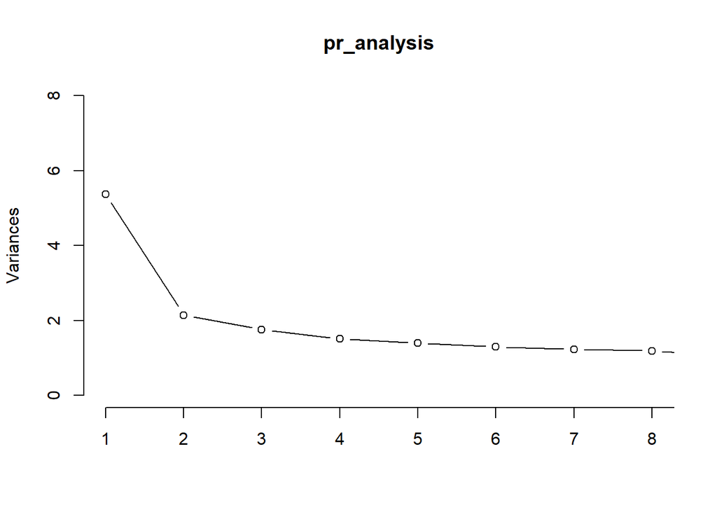

```r
pr_analysis<-prcomp(red_eclsk,scale=TRUE)
screeplot(pr_analysis,ylim=c(0,8),xlim=c(1,8),type = 'l')
```

```r
summary(pr_analysis)
```

```
## Importance of components:
##                           PC1     PC2     PC3     PC4     PC5     PC6    PC7
## Standard deviation     2.3166 1.46477 1.32519 1.23097 1.18172 1.13892 1.1107
## Proportion of Variance 0.1731 0.06921 0.05665 0.04888 0.04505 0.04184 0.0398
## Cumulative Proportion  0.1731 0.24233 0.29898 0.34786 0.39291 0.43475 0.4746
##                            PC8     PC9    PC10    PC11    PC12   PC13    PC14
## Standard deviation     1.08890 1.03544 1.01540 0.99489 0.98488 0.9692 0.93351
## Proportion of Variance 0.03825 0.03458 0.03326 0.03193 0.03129 0.0303 0.02811
## Cumulative Proportion  0.51280 0.54738 0.58064 0.61257 0.64386 0.6742 0.70228
##                           PC15    PC16    PC17    PC18    PC19    PC20    PC21
## Standard deviation     0.91682 0.88712 0.87534 0.85318 0.85075 0.81557 0.80405
## Proportion of Variance 0.02711 0.02539 0.02472 0.02348 0.02335 0.02146 0.02085
## Cumulative Proportion  0.72939 0.75478 0.77949 0.80297 0.82632 0.84778 0.86863
##                           PC22    PC23   PC24    PC25    PC26    PC27   PC28
## Standard deviation     0.77468 0.75754 0.7408 0.67784 0.67096 0.65344 0.6047
## Proportion of Variance 0.01936 0.01851 0.0177 0.01482 0.01452 0.01377 0.0118
## Cumulative Proportion  0.88799 0.90650 0.9242 0.93903 0.95355 0.96733 0.9791
##                           PC29    PC30    PC31
## Standard deviation     0.52506 0.50182 0.34599
## Proportion of Variance 0.00889 0.00812 0.00386
## Cumulative Proportion  0.98802 0.99614 1.00000
```

#### PCA loading

```r
pc1_loadings<-pr_analysis$rotation[,1]
pc1_loadings
```

```
##       WKSESL         RIRT         MIRT     S2KPUPRI     P1EXPECT     P1FIRKDG
##  0.287095458  0.281276196  0.317290877 -0.162402620  0.175281626  0.020255656
##     P1AGEENT     apprchT1     P1HSEVER        chg14     P1FSTAMP     S2KMINOR
##  0.090060945  0.177730648 -0.128798370 -0.039753614 -0.168339414 -0.067173654
##    ONEPARENT     P1NUMSIB      P1HMAFB     WKCAREPK      P1EARLY    wt_ounces
## -0.111229796 -0.009518393  0.226098121  0.078804841 -0.031057029  0.036302261
##     C1FMOTOR     C1GMOTOR     P1HSCALE     P1SADLON     P1IMPULS     P1ATTENI
##  0.196856367  0.096515086 -0.085805133 -0.049417652 -0.125200218 -0.158803814
##      P1SOLVE     P1PRONOU     C6R4MSCL     avg_RIRT     avg_MIRT      avg_SES
## -0.188493193 -0.152153879  0.274278183  0.292245686  0.314561574  0.294637112
## avg_apprchT1
##  0.116793476
```

```r
sorted_pc1_loadings <- sort(abs(pc1_loadings), decreasing = TRUE)
sorted_pc1_loadings
```

```
##         MIRT     avg_MIRT      avg_SES     avg_RIRT       WKSESL         RIRT
##  0.317290877  0.314561574  0.294637112  0.292245686  0.287095458  0.281276196
##     C6R4MSCL      P1HMAFB     C1FMOTOR      P1SOLVE     apprchT1     P1EXPECT
##  0.274278183  0.226098121  0.196856367  0.188493193  0.177730648  0.175281626
##     P1FSTAMP     S2KPUPRI     P1ATTENI     P1PRONOU     P1HSEVER     P1IMPULS
##  0.168339414  0.162402620  0.158803814  0.152153879  0.128798370  0.125200218
## avg_apprchT1    ONEPARENT     C1GMOTOR     P1AGEENT     P1HSCALE     WKCAREPK
##  0.116793476  0.111229796  0.096515086  0.090060945  0.085805133  0.078804841
##     S2KMINOR     P1SADLON        chg14    wt_ounces      P1EARLY     P1FIRKDG
##  0.067173654  0.049417652  0.039753614  0.036302261  0.031057029  0.020255656
##     P1NUMSIB
##  0.009518393
```

#### normality check

Quick check - good enough?

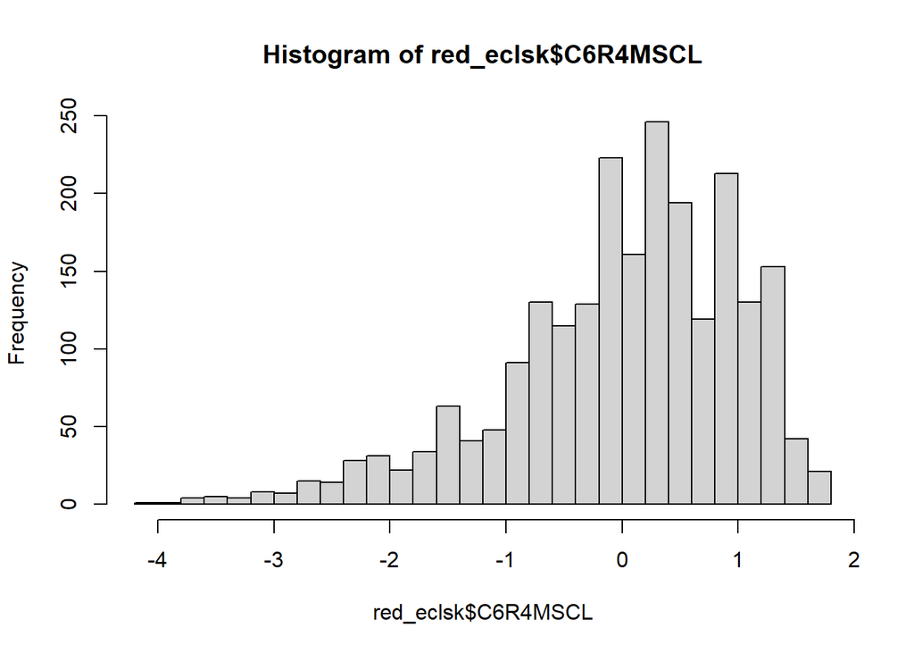

```r
hist(red_eclsk$C6R4MSCL,breaks = "Scott")
```

```r
#ggpairs(red_eclsk)
```

## Preliminary analysis

```r
model_ana<-lm(C6R4MSCL~., data = red_eclsk)
summary(model_ana)
```

```
##
## Call:
## lm(formula = C6R4MSCL ~ ., data = red_eclsk)
##
## Residuals:
##      Min       1Q   Median       3Q      Max
## -2.98349 -0.43193  0.05484  0.50229  1.86091
##
## Coefficients:
##                Estimate Std. Error t value Pr(>|t|)
## (Intercept)   2.220e-16  1.514e-02   0.000 1.000000
## WKSESL        9.394e-02  2.200e-02   4.271 2.03e-05 ***
## RIRT         -1.704e-02  2.322e-02  -0.734 0.463172
## MIRT          5.415e-01  2.578e-02  21.007  < 2e-16 ***
## S2KPUPRI      9.892e-02  1.692e-02   5.846 5.76e-09 ***
## P1EXPECT      8.502e-03  1.690e-02   0.503 0.615057
## P1FIRKDG      8.712e-02  1.590e-02   5.478 4.79e-08 ***
## P1AGEENT     -1.093e-01  1.698e-02  -6.438 1.47e-10 ***
## apprchT1      5.020e-02  2.032e-02   2.471 0.013564 *
## P1HSEVER     -3.376e-02  1.634e-02  -2.066 0.038904 *
## chg14         2.588e-02  1.534e-02   1.687 0.091811 .
## P1FSTAMP      1.812e-03  1.746e-02   0.104 0.917354
## S2KMINOR     -1.034e-02  1.655e-02  -0.625 0.532120
## ONEPARENT    -9.854e-03  1.683e-02  -0.585 0.558288
## P1NUMSIB     -2.839e-03  1.651e-02  -0.172 0.863475
## P1HMAFB       6.526e-02  1.869e-02   3.492 0.000488 ***
## WKCAREPK     -5.624e-03  1.589e-02  -0.354 0.723367
## P1EARLY       3.626e-02  1.792e-02   2.023 0.043172 *
## wt_ounces     1.780e-02  1.807e-02   0.985 0.324602
## C1FMOTOR      1.404e-01  1.727e-02   8.132 6.90e-16 ***
## C1GMOTOR     -2.132e-02  1.596e-02  -1.336 0.181686
## P1HSCALE      5.175e-03  1.561e-02   0.331 0.740319
## P1SADLON     -9.891e-04  1.619e-02  -0.061 0.951293
## P1IMPULS     -4.135e-03  1.688e-02  -0.245 0.806461
## P1ATTENI     -9.520e-03  1.757e-02  -0.542 0.588040
## P1SOLVE      -3.301e-02  1.777e-02  -1.857 0.063433 .
## P1PRONOU     -4.235e-02  1.681e-02  -2.519 0.011827 *
## avg_RIRT      9.143e-03  2.946e-02   0.310 0.756363
## avg_MIRT     -2.845e-02  3.204e-02  -0.888 0.374638
## avg_SES       4.877e-02  2.462e-02   1.981 0.047731 *
## avg_apprchT1  7.422e-03  1.813e-02   0.409 0.682333
## ---
## Signif. codes:  0 '***' 0.001 '**' 0.01 '*' 0.05 '.' 0.1 ' ' 1
##
## Residual standard error: 0.7249 on 2262 degrees of freedom
## Multiple R-squared:  0.4814, Adjusted R-squared:  0.4745
## F-statistic: 69.99 on 30 and 2262 DF,  p-value: < 2.2e-16
```

#### Colinearity tests (all of below)

```r
vif_values <- vif(model_ana)
print(vif_values)
```

```
##       WKSESL         RIRT         MIRT     S2KPUPRI     P1EXPECT     P1FIRKDG
##     2.110414     2.352189     2.898702     1.248824     1.246416     1.103263
##     P1AGEENT     apprchT1     P1HSEVER        chg14     P1FSTAMP     S2KMINOR
##     1.258084     1.800646     1.164043     1.026621     1.330392     1.195112
##    ONEPARENT     P1NUMSIB      P1HMAFB     WKCAREPK      P1EARLY    wt_ounces
##     1.235541     1.188366     1.522956     1.100817     1.400827     1.423561
##     C1FMOTOR     C1GMOTOR     P1HSCALE     P1SADLON     P1IMPULS     P1ATTENI
##     1.301104     1.110412     1.063311     1.143355     1.242518     1.347020
##      P1SOLVE     P1PRONOU     avg_RIRT     avg_MIRT      avg_SES avg_apprchT1
##     1.377966     1.232489     3.786536     4.478694     2.643633     1.433914
```

```r
design_matrix <- model.matrix(model_ana)
svd_values <- svd(design_matrix)
condition_index <- sqrt(max(svd_values$d)/svd_values$d)
```

### General info

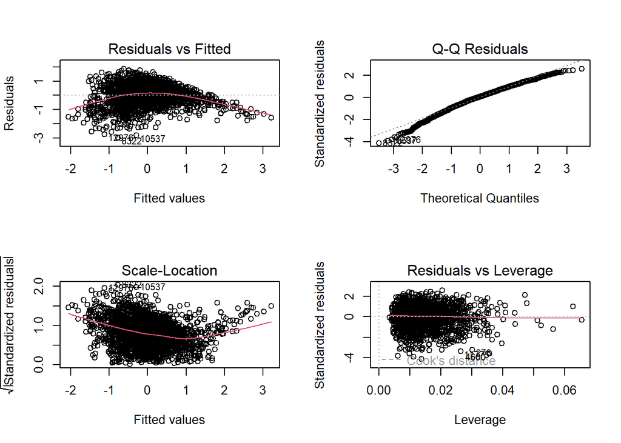

```r
par(mfrow = c(2, 2))
plot(model_ana)
```

### More on non-linearity

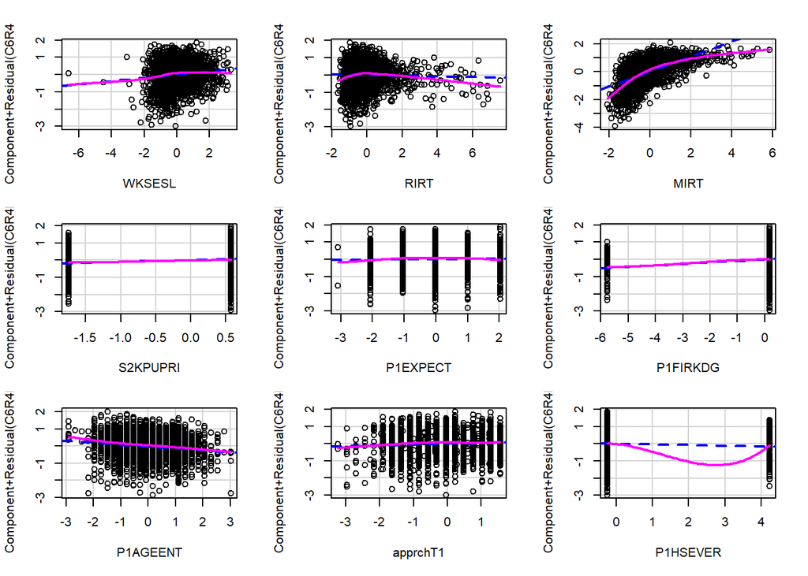

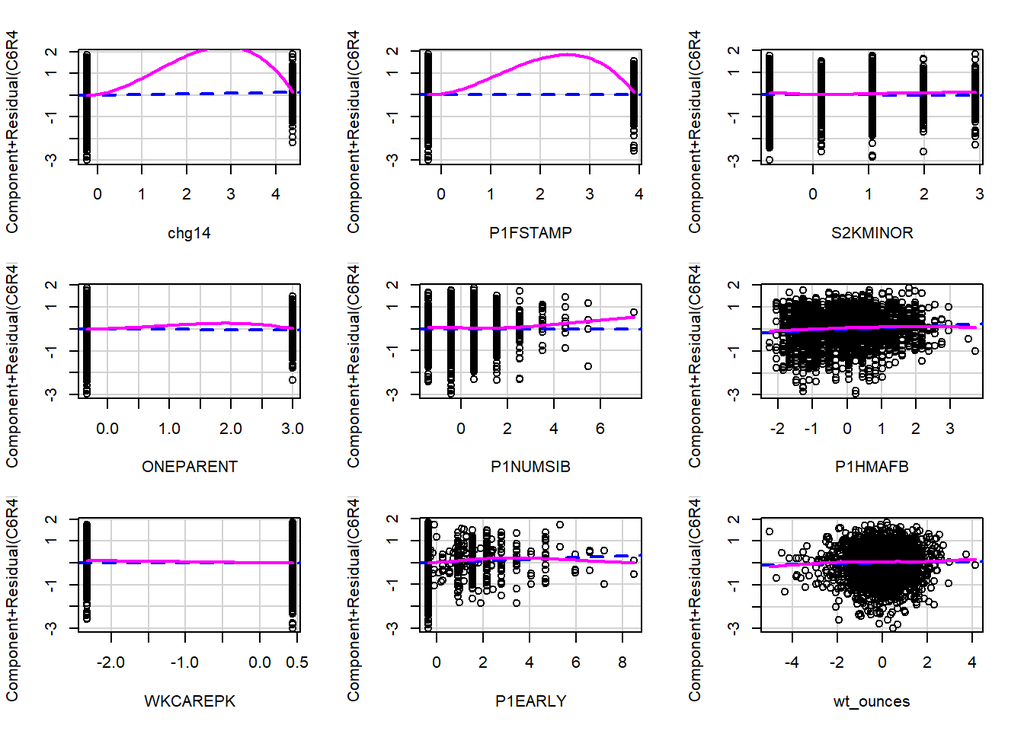

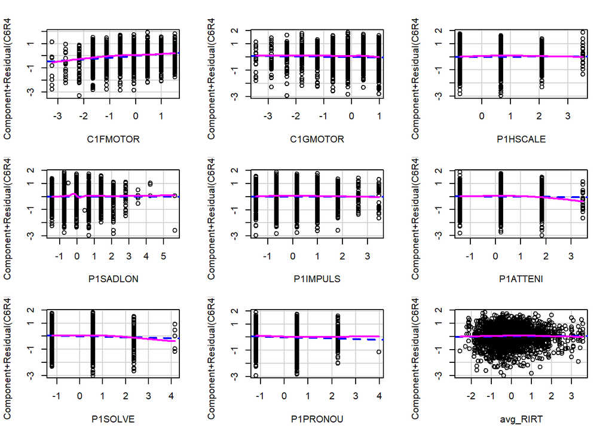

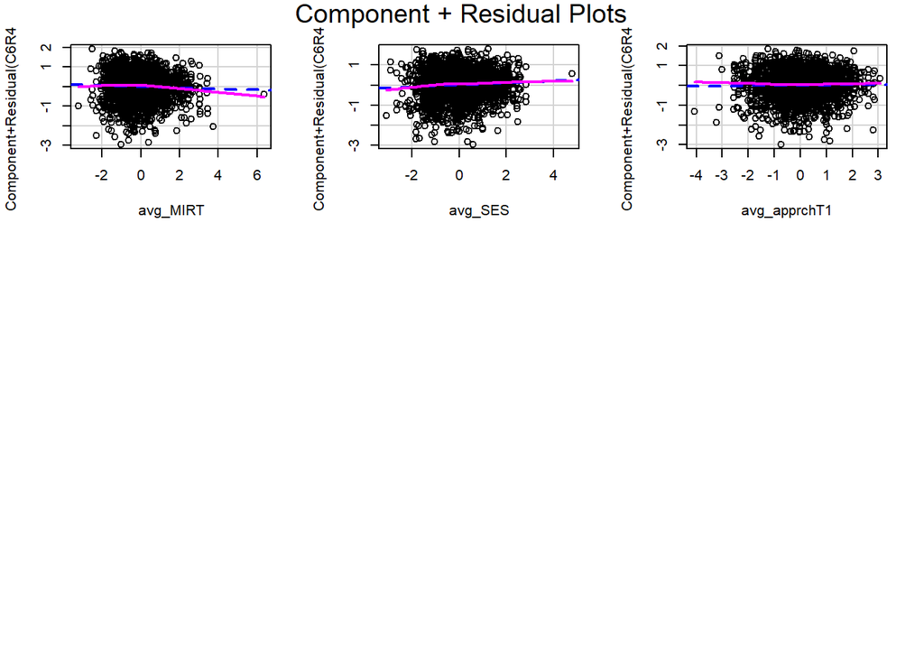

```r
par(mfrow = c(5, 6))
crPlots(model_ana)
```

## First Conclusions

#### homoskedasticity

Not so good, obvious cone-shaped

#### Linearity

Not so good, some curve

# Our aim for the next step:

## Multiple binary regressor:

#### The Gauss-Markov assumption likely to fail: non-homoskedastic as we have observed: $\epsilon ~P_{x_i}, X_i \sim \{0,1\}$

###Definitely some non-linearity here: crPlots()

### And also some high leverage points and high Cook-distance points

### And also some bad predictors.

#### Tentative sub-set of modelling: White, male, disabled kids with two parents that never attended head-start, never changed school, never used foodstamp, and went to special education. (size 1755 before further reduction.)

```r
##
```

```r
##setwd(dir = "F:")
##eclsk_df <- readECLS_K2011(filename = "childK5p.dat",
 ##                          layoutFilename = "ECLSK2011_K5PUF.sps",
  ##                         forceReread = FALSE,
   ##                        verbose = TRUE)
```